# Mini Project 2

The system of Partial Differential equations (PDEs) that I will be solving numerically are from “A model mechanism for the chemotactic response of endothelial cells to tumour angiogenesis facctor” written by M.a.J.Chaplain ad A.M. Stuart in 1993.

The system of PDEs that I will be solving are
$$\begin{equation}
\frac{\delta c}{\delta t} = \frac{\delta ^2 c}{\delta x^2} - \frac{\alpha n c}{\gamma + c}-\lambda c
\end{equation}$$
$$\begin{equation}
\frac{\delta n}{\delta t} = D \frac{\delta ^2 n}{\delta x^2} - \kappa \frac{\delta}{\delta x} \left( n \frac{\delta c}{\delta x} \right) + \mu n (1-n) G(c) - \beta n
\end{equation}$$
where
$$\begin{equation}
G(c) = \begin{cases} 0, & \mbox{if } c \leq c^{*} \\ c-c^{*}, & \mbox{if } c^{*} < c \end{cases}
\end{equation}$$
The initial and boundary conditions are respectively
$$c(x,0)= c_0 (x),$$
$$\begin{equation}
n(x,0) = \begin{cases} 1, & \mbox{if } x=1 \\ 0, & \mbox{if } x<1 \end{cases}
\end{equation}$$
$$c(0,t) = 1, \hspace{10mm} c(1,t)=0,$$
$$n(1,t)=1,$$
$$\begin{equation}
\frac{\delta n}{\delta x}(0,t) = 0
\end{equation}$$

The systems variables are concentration of Tumour Angiogenesis Factor (TAF) $c$, the endothelial cell density $n$ over unit time $t$ and over a distance $x$ from the tumour. The system describes the rate of change in TAF concentration over time and the rate of change in density of endothelial cells over time. Below is a list of the constants in the equations and there meaning in terms of the model:

$D$ - Diffusion coefficient

$\kappa$ - Chemotactic parameter

$\mu$ - Cell proliferation parameter

$\beta$ - Cell loss parameter

$\lambda$ - Distance between the tumour and vessel over the diffusion coefficient.

$\alpha$ - Distance between the tumour and vessel over the diffusion of TAF

The error term for the equations that we have so far is $O(h^2)$ and there will also be $O(\tau)$ for the first order differential at the beginning of the equation. The overall error term is $O(h^2 + \tau)$ which is condsidered satisfactory for most problems.

First choose step sizes for time and distance. Use two for time steps as one to record the results other just as steps.

```r
h <- 0.1
N <- 500
x <- (0:N)*h

tau <- 0.1
M <- 5000
M1 <- 100
M2 <- round(M/M1)
t <- (0:M1)*M2*tau
```

Create two matrices to hold the approximations for $c_{k,j}$ and $n_{k,j}$ from $0$ to $M$ and $N$,

```r
wc <- matrix(0, nrow=N+1, ncol=M1+1)
wn <- matrix(0, nrow=N+1, ncol=M1+1)
```

We also initialise all of the parameters that are in the PDEs

```r
D <- 0.001
kappa <- 0.75
mu <- 100
beta <- 4
gam <- 1
alpha <- 10
lambda <- 1
```

We then need to create vectors that hold the values for $c_{k,j}$, $c_{k+1,j}$, $c_{k-1,j}$, $n_{k,j}$, $n_{k+1,j}$ and $n_{k-1,j}$. After creating vectors we can use the formula calculated above to find the values $c_{k,j+1}$ and $n_{k,j+1}$. The values are then assigned to the matrices which hold the solutions.

For the forward difference explicit method we get a full function as follows:

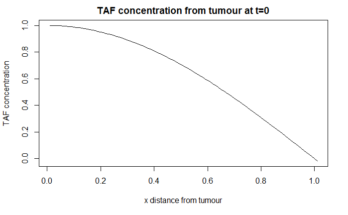

```r
TAF <- function(deltac=function(x) 0*x, deltan=function(x) 0*x, G=function(x) 0*x,
                alpha=10, gamma=1, lambda=1, D=0.001, kappa=0.75, mu=100, beta=4,
                N=1000, L=1, T=1, M=100000) {

  ##Creating step size for distance
  h <- L/N
  x <- (0:N+1)*h

  ##Creating step size for time
  tau <- T/M
  M1 <- 100
  M2 <- round(M/M1)
  t <- (0:M1)*M2*tau

  ##Creating the matrices to hold results
  wc <- matrix(0, nrow=N+1, ncol=M1+1)
  wn <- matrix(0, nrow=N+1, ncol=M1+1)

  ##Initial condition functions
  Cn <- deltac(x) +0*x
  ENn <- deltan(x) + 0*x

  ##Setting initial conditions
  wc[,1] <- Cn
  wn[,1] <- ENn

  ##Running through time steps for M1, M2 amount of times to M1*M2=M time steps all together
  for (j in 1:M1){
    for (j2 in 1:M2) {

      C <- Cn
      Cp <- c(C[2:(N+1)],C[N])
      Cm <- c(C[2], C[1:N])

      EN <- ENn
      ENp <- c(EN[2:(N+1)], EN[N-1])
      ENm <- c(EN[2], EN[1:N])

      ##Equation shown calculations for above (TAF)
      Cn <- C + tau*(
        (Cp - 2*C + Cm)/(h*h)
        - (alpha*EN*C)/(gamma+C)
        - lambda*C)

      ##Equation for Endothelial cell density as shown above.
      ENn <- EN + tau*(
        (D*(ENp -2*EN + ENm))/(h*h)
        - (kappa*((ENp-EN)*(Cp-C) - (EN-ENm)*(C-Cm)))/(2*h*h)
        + mu*EN*(1-EN)*G(C)
        -beta*EN)

    }
    ##Saving value for each M2 time step
    wc[,j+1] <- Cn
    wn[,j+1] <- ENn
  }
  ##Returns list of distance and time vectors and Matrices holding TAF concentration and Endothelial cell density
  list(x=x, t=t, C=wc, EN=wn)
}
##Setting intial conditions for both as suggested by the paper
deltac <- function(x) cos((pi/2)*x)
deltan <- function(x) ifelse(x==1, 1, 0)
##Giving the function within PDE in the paper.
G <- function(x) ifelse(x<=0.2, 0, x-0.2)
##Solving PDE for initial conditions
sol <- TAF(deltac=deltac, deltan=deltan, G=G,alpha=10, gamma=1, lambda=1, D=0.001, kappa=0.75, mu=100, beta=4,
           N=100, L=1, T=1, M=10000)
##Plotting the solution at time 0 for TAF concentration.
plot(sol$x, sol$C[,1], type="l", xlab="x distance from tumour", ylab="TAF concentration", main="TAF concentration from tumour at t=0")
```

```r
NA
```

The graph above is similar to the graph in the paper studied (Figure 1 (a)).

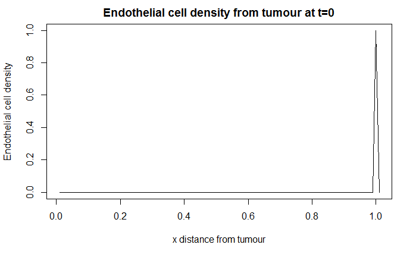

```r
plot(sol$x, sol$EN[,1], type="l", xlab="x distance from tumour", ylab="Endothelial cell density", main="Endothelial cell density from tumour at t=0")
```

```r
NA
```

One particular difficulty faced with this problem is stability as within the paper after a time of 0.7 units the method that is used by the authors is considered unstable as it doesn’t fit to the results accurately enough.

Another note is to raise the point as to what the results are showing. The results are pretty accurate when compared with impirical research. However, as noted by the authors after $t=0.7$. The results become less reliable. The authors argue that to make the system better still it might be appropriate to add more variables, one particular additional system to add could be to include the sprout growths of the tumour. This effects both the TAF concentration and endothelial cell density. Perhaps adding this into the system may make the results more reliable after the $t=0.7$ time?

The results could be improved by using an implicit method. The Backwards difference method using the double sweep algorithm could improve the results and definitely improve the stability of the results.